# Research Designs, Causation and Correlation

Simon Kiss

March 30, 2020

# Causation

1. Luck
2. Correlation
3. Other explanations

# Correlation

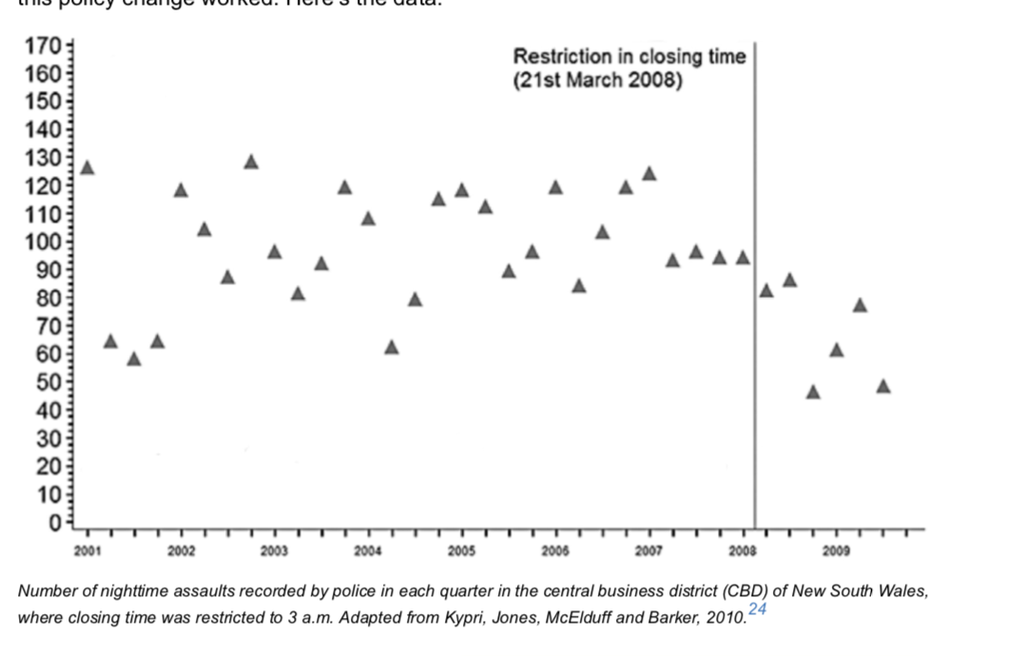

# Correlation

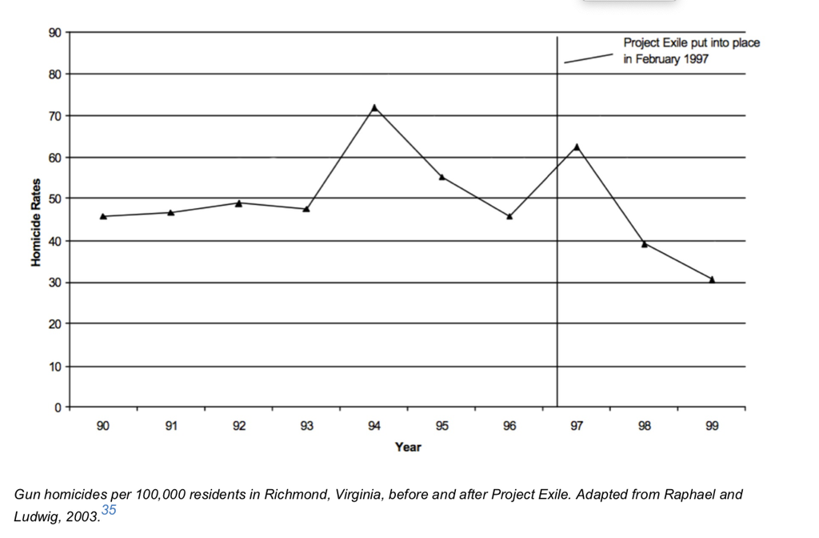

# Correlation

Correlation does not = causation, but correlation always is necessary for causation.

“Correlation doesn’t imply causation, but it does waggle its eyebrows suggestively and gesture furtively while mouthing ‘look over there’;”

# Correlation

## Problems with correlation

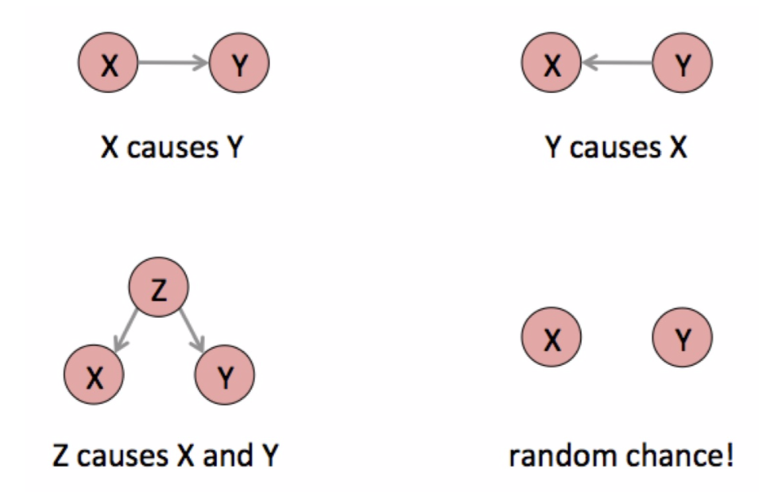

# Research Designs

1. A particular way of gathering data to test hypotheses
2. Each have particular advantages and disadvantages
   1. Cross-sectional
   2. Experiments

# Research Designs

## Cross-sectional

1. take a single snapshot of some phenonenon at a time
   - example: surveys
2. Very good at establishing correlations
3. Can be good at controlling for other explanations
4. Terrible at assessing causation.

# Research designs

## Cross-sectional

> Researchers find fewer depressive symptoms in dark-chocolate eaters Out of 13,000 people they surveyed, about 7.6 per cent overall said they felt depressive symptoms, while only 1.5 per cent of chocolate-eaters in that group reported feeling those symptoms. [Source: CTV News](https://www.ctvnews.ca/lifestyle/researchers-find-fewer-depressive-symptoms-in-dark-chocolate-eaters-1.4532678)[^1]

# Research designs

## Cross-sectional

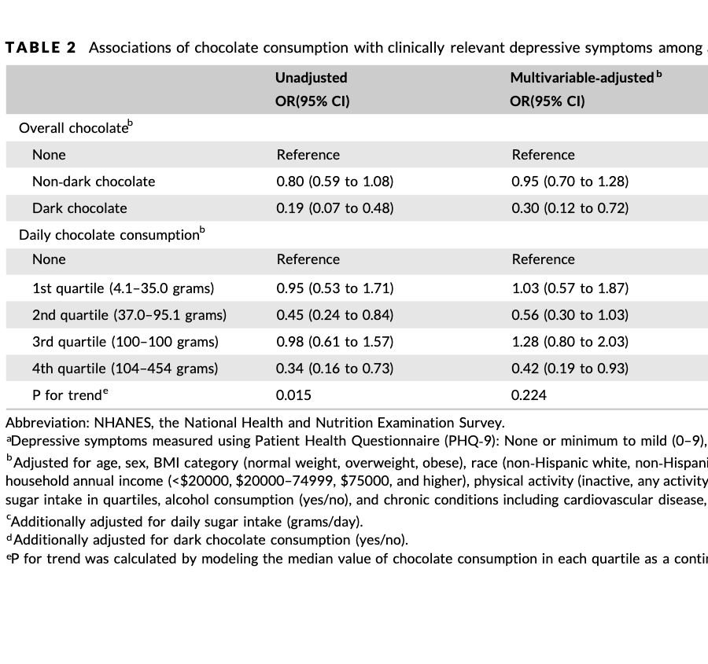

# Research designs

## Cross-sectional

2. What are the possible causal interpretations of these data?
   - eating chocolate might make you feel less depressed ( x might cause y)
   - being depressed might cause you to eat chocolate (y might cause x)
   - Something else might cause depression *and* a propensity to eat chocolate (e.g. low levels of education, stressful job might cause both x and y)
   - x and y relationship might actually be luck
     - large sample size, low p-values of findings are supposed to guard against this, but remember the jelly bean comic and publication bias

# Research Designs

## Experiments

1. Technical name is Randomized Control Trial (RCT)
2. Seen as gold standard
3. Basic logic is to distinguish between causal models
   - Randomly assign participants to a *treatment* group that gets the hypothesized cause or a *control* group that does not
   - in theory treatments are the only thing that distinguish random from control groups

# Research Designs

## Experiments

Have their own problems.

1. hard to do for really interesting questions, expensive
   - How do you test the effects of poverty on future life happiness with an experiment
2. Can you really replicate the real world in a lab?

# Research Designs

## Experiments

There are some variations on experiments at a large scale

1. Quasi-experiments
   - take advantage of natural variation in the world
   - the Richmond homicide example and the Hamilton pub closing time examples are great examples of these.

# Research Designs

## Experiments

There are some variations on experiments at a large scale

1. Quasi-experiments are variations on experiments at a large scale
   - take advantage of natural variation in the world
   - the Richmond homicide example and the Hamilton pub closing time examples are great examples of these.

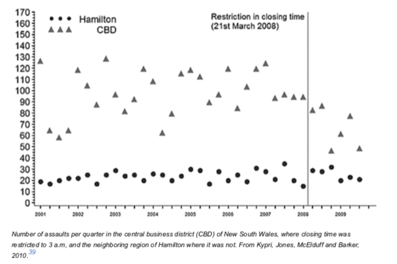

# Research Designs

## Experiments

- Williams (1986)[^2]
  - researchers studied the impact of the introduction of television on three remote communities
  - one had no television, two others did.
  - Violence in playgrounds increased

# Falsification

- Falsification, not proof
- scientific explanations are always uncertain
- good because it encourages debate, criticism and avoids dogma and deference to authority
[^1]: [Jackson, Sarah E., Lee Smith, Joseph Firth, Igor Grabovac, Pinar Soysal, Ai Koyanagi, Liang Hu, Brendon Stubbs, Jacopo Demurtas, and Nicola Veronese. 2019. “Is There a Relationship between Chocolate Consumption and Symptoms of Depression? A Cross-Sectional Survey of 13,626 US Adults.” *Depression and Anxiety* 36 (10): 987–995.](https://onlinelibrary.wiley.com/doi/abs/10.1002/da.22950)
[^2]: Williams (ed), T. M. 1986. The Impact of Television: A Natural Experiment in Three Communities. Academic Press.